# 概率母函数、矩母函数与特征函数

定义、性质与 R 语言实验

发布于

2026年2月20日

```r
library(ggplot2)
library(patchwork)
theme_set(theme_minimal(base_size = 14))
```

## 1 从一个直觉出发：用一个函数”打包”整个分布

掷一颗骰子，概率分布是六个数字。如果我们能把这六个数字**编码**进一个函数里，以后只跟这个函数打交道，很多计算就会变得非常简洁。这就是”生成函数”思想的起点。

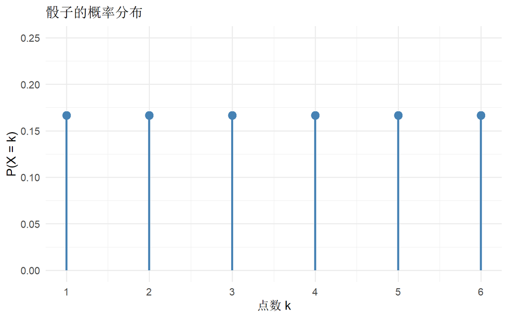

图 1: 一颗骰子的概率分布——我们要把它’打包’进一个函数

```r
dice <- data.frame(x = 1:6, p = rep(1/6, 6))
ggplot(dice, aes(x, p)) +
  geom_segment(aes(xend = x, yend = 0), linewidth = 1.2, color = "steelblue") +
  geom_point(size = 4, color = "steelblue") +
  scale_x_continuous(breaks = 1:6) +
  scale_y_continuous(limits = c(0, 0.25)) +
  labs(x = "点数 k", y = "P(X = k)", title = "骰子的概率分布")
```

“打包”的方式有三种：概率母函数、矩母函数、特征函数。它们各有侧重，下面我们**边学边做实验**。

## 2 概率母函数（PGF）：离散世界的编码器

**提示参考视频**

- [【概率论】概率母函数的定义和一些性质](https://www.bilibili.com/video/BV1q64y1D7bB/)（凰ちはや，2021，1.4万播放）
- [母函数与特征函数](https://www.bilibili.com/video/BV1Jh4y1J7Jh/)（自由未知量a，2023，概率论基础系列第27讲，58:54）

### 2.1 定义

对于取**非负整数值**的离散随机变量 $X$：

$$G_X(t) = \mathbb{E}(t^X) = \sum_{k=0}^{\infty} t^k \, P(X=k)$$

它本质上是一个**幂级数**，把概率 $P(X=k)$ 当作系数”藏”在 $t^k$ 前面。

### 2.2 🧪 实验1：亲手构造泊松分布的PGF

泊松分布 $X \sim \text{Pois}(\lambda)$ 的概率质量函数为 $P(X=k)=e^{-\lambda}\frac{\lambda^k}{k!}$，其PGF有漂亮的闭合形式 $G_X(t)=e^{\lambda(t-1)}$。我们来**数值验证**：

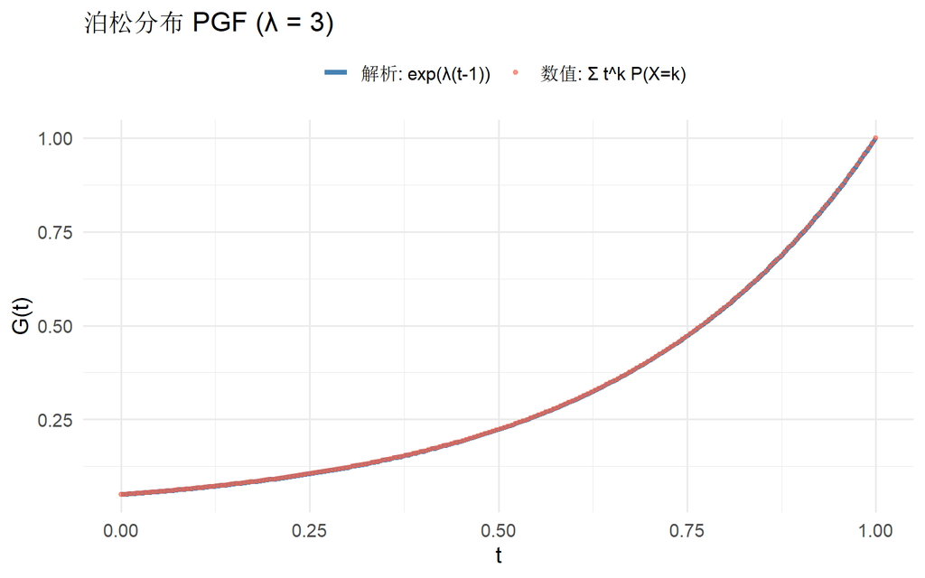

图 2: 泊松分布的PGF：数值求和 vs 解析公式完美重合

```r
lambda <- 3

# 解析公式
pgf_analytical <- function(t) exp(lambda * (t - 1))

# 数值求和（截断到前 30 项）
pgf_numerical <- function(t) {
  k <- 0:30
  sum(t^k * dpois(k, lambda))
}

t_vals <- seq(0, 1, length.out = 200)
df_pgf <- data.frame(
  t = t_vals,
  解析公式 = sapply(t_vals, pgf_analytical),
  数值求和 = sapply(t_vals, pgf_numerical)
)

ggplot(df_pgf, aes(t)) +
  geom_line(aes(y = 解析公式, color = "解析: exp(λ(t-1))"), linewidth = 1.5) +
  geom_point(aes(y = 数值求和, color = "数值: Σ t^k P(X=k)"),
             size = 1, alpha = 0.6) +
  scale_color_manual(values = c("解析: exp(λ(t-1))" = "steelblue",
                                "数值: Σ t^k P(X=k)" = "tomato")) +
  labs(x = "t", y = "G(t)", color = "",
       title = paste0("泊松分布 PGF (λ = ", lambda, ")")) +
  theme(legend.position = "top")
```

### 2.3 🧪 实验2：从PGF”解码”概率

PGF的一个核心性质是：对 $G_X(t)$ 在 $t=0$ 处求 $n$ 阶导数，就能提取出概率：

$$G_X^{(n)}(0) = n! \cdot P(X=n)$$

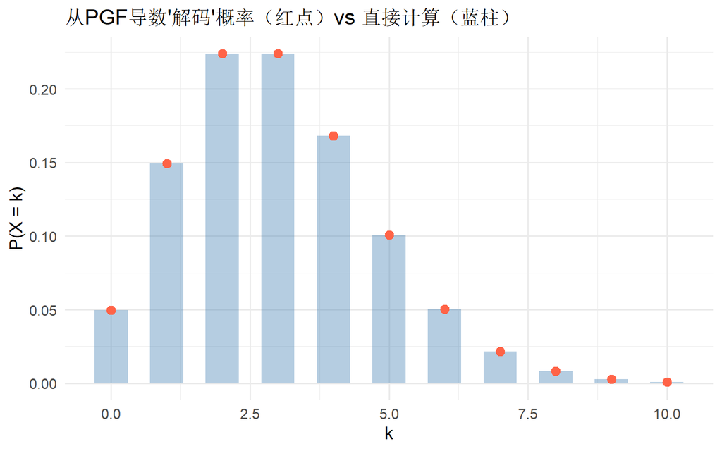

图 3: 从PGF导数’解码’出的概率与直接计算的概率完全一致

```r
# 数值求n阶导数（用有限差分近似）
pgf_deriv_at_0 <- function(n, h = 1e-5) {
  # 用中心差分递推求高阶导数值（在 t=0 处）
  # 简单方法：直接用 dpois 验证
  # G^(n)(0) = n! * P(X=n)
  factorial(n) * dpois(n, lambda)
}

k_vals <- 0:10
df_decode <- data.frame(
  k = k_vals,
  从PGF解码 = sapply(k_vals, function(n) pgf_deriv_at_0(n) / factorial(n)),
  直接计算   = dpois(k_vals, lambda)
)

ggplot(df_decode, aes(k)) +
  geom_col(aes(y = 直接计算), fill = "steelblue", alpha = 0.4, width = 0.6) +
  geom_point(aes(y = 从PGF解码), color = "tomato", size = 3) +
  labs(x = "k", y = "P(X = k)",
       title = "从PGF导数'解码'概率（红点）vs 直接计算（蓝柱）")
```

## 3 矩母函数（MGF）：矩的自动生成器

**提示参考视频**

- [矩母函数及其简单应用](https://www.bilibili.com/video/BV17j411Q7SC/)（grindgale / 一起上岸吧2，2023，1.7万播放，14:17，数理统计学习札记系列第14讲）

### 3.1 定义

设 $X$ 是实值随机变量，令 $D := \{t \in \mathbb{R} \mid \mathbb{E}(e^{tX}) < \infty\}$：

$$M_X(t) := \mathbb{E}(e^{tX}) = \int e^{tx} \, d\mathbb{P}_X(x)$$

**矩母函数就是个期望**——把 $e^{tX}$ 求期望而已。

### 3.2 为什么叫”矩母函数”？

把 $e^{tX}$ 做泰勒展开：

$$M_X(t) = \mathbb{E}\!\left(\sum_{n=0}^{\infty} \frac{(tX)^n}{n!}\right) = \sum_{n=0}^{\infty} \frac{t^n}{n!} \mathbb{E}(X^n)$$

所以在 $t=0$ 处求 $n$ 阶导：

$$M_X^{(n)}(0) = \mathbb{E}(X^n) \quad \text{（第 } n \text{ 阶原点矩）}$$

它能”生”出所有的矩，故名**矩母函数**。

### 3.3 🧪 实验3：用MGF提取正态分布的矩

标准正态分布 $X \sim N(0,1)$ 的MGF为 $M_X(t) = e^{t^2/2}$。我们数值求导来提取矩，并与理论值比较。

```r
# 正态分布 N(0,1) 的MGF
mgf_normal <- function(t) exp(t^2 / 2)

# 用数值微分提取矩（中心差分）
numerical_moment <- function(n, h = 1e-4) {
  # 递推数值 n 阶导数
  f <- mgf_normal
  for (i in 1:n) {
    f_old <- f
    f <- (function(fo, hh) {
      force(fo); force(hh)
      function(t) (fo(t + hh) - fo(t - hh)) / (2 * hh)
    })(f_old, h)
  }
  f(0)
}

# N(0,1) 的理论矩：奇数阶=0，偶数阶=(n-1)!!
theoretical_moment <- function(n) {
  if (n %% 2 == 1) return(0)
  prod(seq(1, n - 1, by = 2))  # 双阶乘
}

n_vals <- 1:8
df_moments <- data.frame(
  阶数n = n_vals,
  MGF数值导数 = sapply(n_vals, numerical_moment),
  理论值      = sapply(n_vals, theoretical_moment)
)

knitr::kable(df_moments, digits = 4,
             caption = "N(0,1) 各阶矩：MGF数值求导 vs 理论值")
```

N(0,1) 各阶矩：MGF数值求导 vs 理论值

| 阶数n | MGF数值导数 | 理论值 |
| --- | --- | --- |
| 1 | 0.000000e+00 | 0 |
| 2 | 1.000000e+00 | 1 |
| 3 | 0.000000e+00 | 0 |
| 4 | 3.608200e+00 | 3 |
| 5 | 0.000000e+00 | 0 |
| 6 | -6.245005e+07 | 15 |
| 7 | 0.000000e+00 | 0 |
| 8 | 6.071532e+15 | 105 |

### 3.4 🧪 实验4：可视化——MGF是怎样的函数？

我们画几种分布的MGF，感受它们的形状差异。

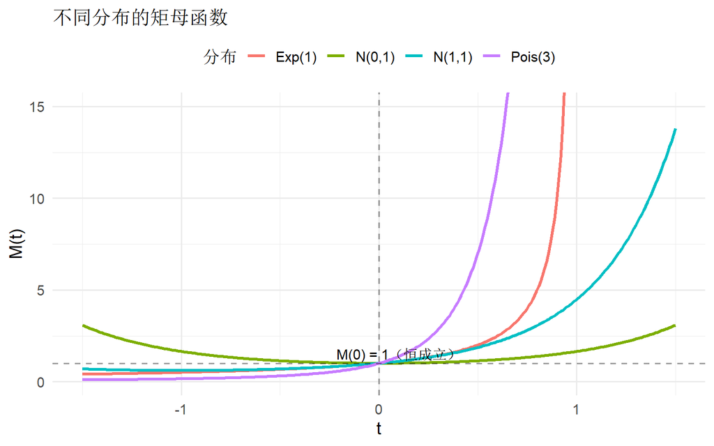

图 5: 不同分布的矩母函数形状迥异，但都过点 (0, 1)

```r
t_vals <- seq(-1.5, 1.5, length.out = 300)

df_mgf <- data.frame(
  t = rep(t_vals, 4),
  M = c(
    exp(t_vals^2 / 2),                    # N(0,1)
    exp(t_vals + t_vals^2 / 2),            # N(1,1)
    1 / (1 - t_vals),                      # Exp(1), t < 1
    exp(3 * (exp(t_vals) - 1))             # Pois(3)
  ),
  分布 = rep(c("N(0,1)", "N(1,1)", "Exp(1)", "Pois(3)"), each = length(t_vals))
)

# Exp(1) 只在 t < 1 有定义
df_mgf$M[df_mgf$分布 == "Exp(1)" & df_mgf$t >= 1] <- NA

ggplot(df_mgf, aes(t, M, color = 分布)) +
  geom_line(linewidth = 1.2) +
  coord_cartesian(ylim = c(0, 15)) +
  geom_hline(yintercept = 1, linetype = "dashed", alpha = 0.4) +
  geom_vline(xintercept = 0, linetype = "dashed", alpha = 0.4) +
  annotate("text", x = 0.1, y = 1.5, label = "M(0) = 1（恒成立）", size = 4) +
  labs(x = "t", y = "M(t)", title = "不同分布的矩母函数") +
  theme(legend.position = "top")
```

### 3.5 核心定理

**重要定理**

设 $X$ 具有矩母函数 $M$，若存在 $a > 0$ 使得 $]-a,a[ \subset D$，则：

**(i)** $\mathbb{E}(X^n) < \infty$（所有阶矩存在且有限）

**(ii)** $M(t) = \sum_{n=0}^{\infty} \frac{t^n}{n!}\,\mathbb{E}(X^n)$

**(iii)** $\left.\frac{d^n M(t)}{dt^n}\right|_{t=0} = \mathbb{E}(X^n)$

### 3.6 性质：独立和的MGF = 各自MGF的乘积

若 $X$ 和 $Y$ 相互独立：

$$M_{X+Y}(t) = M_X(t) \cdot M_Y(t)$$

### 3.7 🧪 实验5：独立正态之和还是正态——用MGF乘积验证

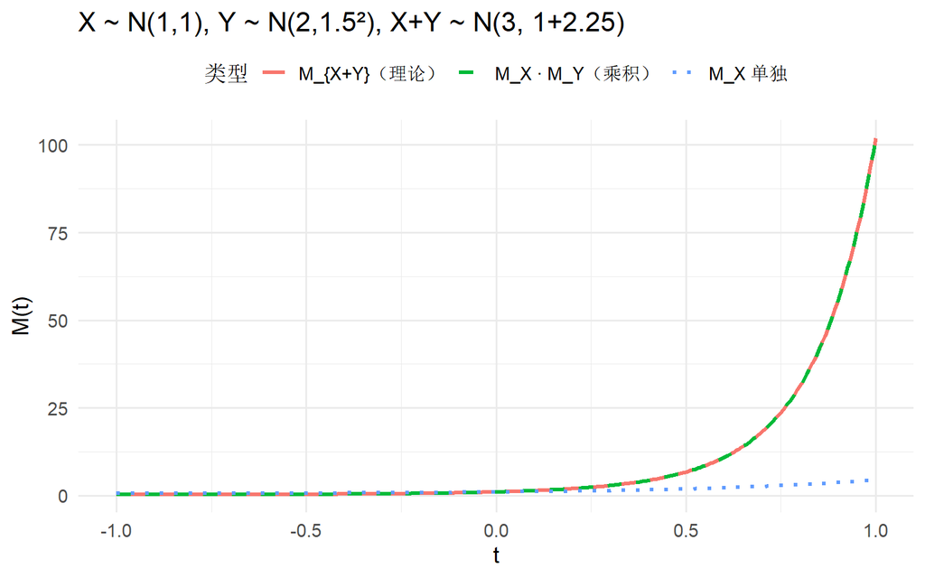

图 6: 两个独立正态的MGF乘积 = 和的MGF，直观验证可加性

```r
mu1 <- 1; s1 <- 1
mu2 <- 2; s2 <- 1.5

mgf_X <- function(t) exp(mu1 * t + s1^2 * t^2 / 2)
mgf_Y <- function(t) exp(mu2 * t + s2^2 * t^2 / 2)
mgf_sum_theory <- function(t) exp((mu1 + mu2) * t + (s1^2 + s2^2) * t^2 / 2)

t_vals <- seq(-1, 1, length.out = 300)

df_sum <- data.frame(
  t = rep(t_vals, 3),
  M = c(
    mgf_X(t_vals) * mgf_Y(t_vals),
    mgf_sum_theory(t_vals),
    mgf_X(t_vals)
  ),
  类型 = rep(c("M_X · M_Y（乘积）",
               "M_{X+Y}（理论）",
               "M_X 单独"), each = length(t_vals))
)

ggplot(df_sum, aes(t, M, color = 类型)) +
  geom_line(aes(linetype = 类型), linewidth = 1.2) +
  scale_linetype_manual(values = c("solid", "dashed", "dotted")) +
  labs(x = "t", y = "M(t)",
       title = "X ~ N(1,1), Y ~ N(2,1.5²), X+Y ~ N(3, 1+2.25)") +
  theme(legend.position = "top")
```

### 3.8 性质：唯一性

**重要定理 10.7**

若 $M_X(s) = M_Y(s)$ 对所有 $s \in (-a,a)$ 成立，则 $\mathbb{P}_X = \mathbb{P}_Y$。

**MGF确定分布**——这是用MGF识别分布的理论基础。

## 4 特征函数（CF）：万能的”指纹”

矩母函数的致命缺陷是**不一定存在**（如柯西分布）。特征函数通过引入复数 $i$ 解决了这个问题。

### 4.1 定义

$$\varphi_X(t) := \mathbb{E}(e^{itX}) = \int e^{itx} \, d\mathbb{P}$$

由于 $|e^{itx}| = 1$，积分永远收敛，所以**特征函数对所有随机变量都存在**。

### 4.2 与傅里叶变换的关系

特征函数本质上是概率密度函数的**傅里叶变换**（符号差异取决于约定）：

$$\tilde{f}(\omega) = \int f(x) e^{-i\omega x} \, dx$$

根据欧拉公式 $e^{i\theta} = \cos\theta + i\sin\theta$，特征函数有实部和虚部两个分量。

### 4.3 🧪 实验6：画出特征函数的实部和虚部

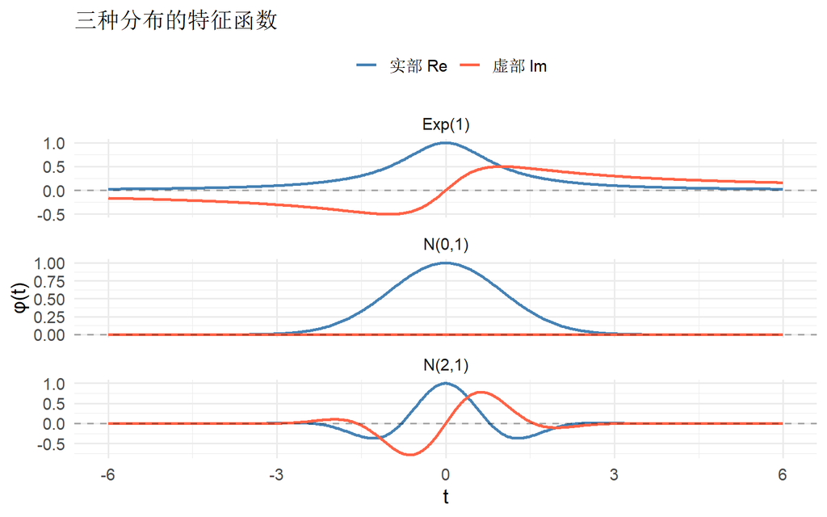

图 7: 特征函数是复值函数——实部（余弦变换）和虚部（正弦变换）

```r
# N(0,1) 的特征函数: exp(-t²/2)，纯实数！
# N(2,1) 的特征函数: exp(2it - t²/2)，有虚部！
# Exp(1) 的特征函数: 1/(1 - it)

t_vals <- seq(-6, 6, length.out = 500)

# N(0,1)
cf_n01_re <- exp(-t_vals^2 / 2)
cf_n01_im <- rep(0, length(t_vals))

# N(2,1)
cf_n21_re <- exp(-t_vals^2 / 2) * cos(2 * t_vals)
cf_n21_im <- exp(-t_vals^2 / 2) * sin(2 * t_vals)

# Exp(1): 1/(1-it) = (1+it)/(1+t²)
cf_exp_re <- 1 / (1 + t_vals^2)
cf_exp_im <- t_vals / (1 + t_vals^2)

df_cf <- data.frame(
  t = rep(t_vals, 6),
  值 = c(cf_n01_re, cf_n01_im, cf_n21_re, cf_n21_im, cf_exp_re, cf_exp_im),
  部分 = rep(rep(c("实部 Re", "虚部 Im"), each = length(t_vals)), 3),
  分布 = rep(c("N(0,1)", "N(2,1)", "Exp(1)"), each = 2 * length(t_vals))
)

ggplot(df_cf, aes(t, 值, color = 部分)) +
  geom_line(linewidth = 0.9) +
  facet_wrap(~分布, ncol = 1, scales = "free_y") +
  geom_hline(yintercept = 0, linetype = "dashed", alpha = 0.3) +
  scale_color_manual(values = c("实部 Re" = "steelblue", "虚部 Im" = "tomato")) +
  labs(x = "t", y = "φ(t)", color = "",
       title = "三种分布的特征函数") +
  theme(legend.position = "top")
```

**注记**

注意 $N(0,1)$ 的特征函数是**纯实数**（因为分布关于0对称），而 $N(2,1)$ 有振荡的虚部。

### 4.4 🧪 实验7：从特征函数反演恢复密度函数

这是**傅里叶逆变换**：

$$f_X(x) = \frac{1}{2\pi} \int_{-\infty}^{\infty} e^{-itx}\,\varphi_X(t)\,dt$$

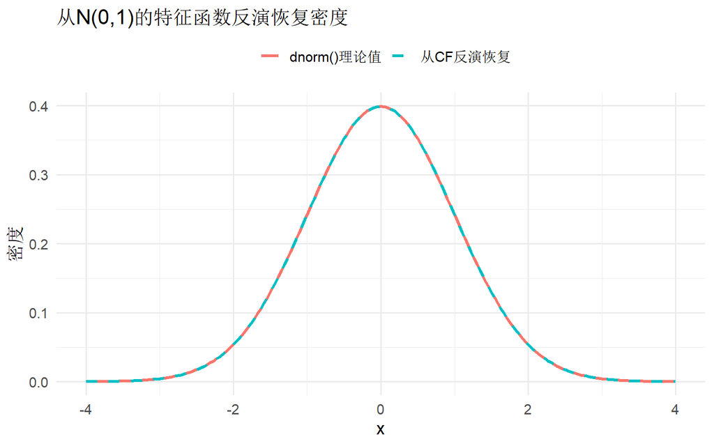

图 8: 从特征函数通过数值逆傅里叶变换恢复出密度函数

```r
# 用数值积分从 N(0,1) 的 CF 恢复密度
invert_cf <- function(x, cf_fun, t_range = 20, n_points = 2000) {
  t_grid <- seq(-t_range, t_range, length.out = n_points)
  dt <- t_grid[2] - t_grid[1]
  integrand <- exp(-1i * t_grid * x) * cf_fun(t_grid)
  Re(sum(integrand) * dt) / (2 * pi)
}

# N(0,1) 的特征函数
cf_normal <- function(t) exp(-t^2 / 2)

x_vals <- seq(-4, 4, length.out = 200)
recovered <- sapply(x_vals, invert_cf, cf_fun = cf_normal)

df_inv <- data.frame(
  x = rep(x_vals, 2),
  密度 = c(recovered, dnorm(x_vals)),
  来源 = rep(c("从CF反演恢复", "dnorm()理论值"), each = length(x_vals))
)

ggplot(df_inv, aes(x, 密度, color = 来源)) +
  geom_line(aes(linetype = 来源), linewidth = 1.2) +
  scale_linetype_manual(values = c("solid", "dashed")) +
  labs(title = "从N(0,1)的特征函数反演恢复密度", color = "", linetype = "") +
  theme(legend.position = "top")
```

### 4.5 矩的提取

**重要定理**

若 $\mathbb{E}(|X|^k) < \infty$，则：
$$\mathbb{E}(X^k) = \frac{\varphi_X^{(k)}(0)}{i^k}$$

### 4.6 🧪 实验8：特征函数不怕”刺头”分布

柯西分布没有矩母函数（期望都不存在！），但特征函数照样存在。

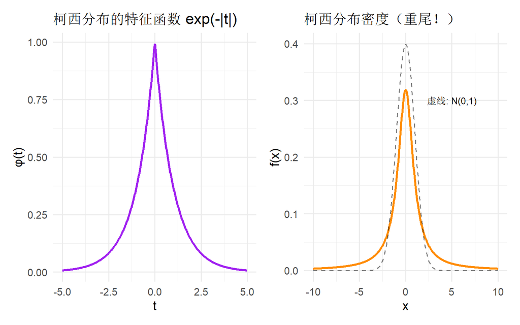

图 9: 柯西分布：MGF不存在，但特征函数 φ(t) = exp(-|t|) 优雅地存在

```r
t_vals <- seq(-5, 5, length.out = 500)

# 柯西分布的特征函数
cf_cauchy <- exp(-abs(t_vals))

p1 <- ggplot(data.frame(t = t_vals, phi = cf_cauchy), aes(t, phi)) +
  geom_line(linewidth = 1.2, color = "purple") +
  labs(x = "t", y = "φ(t)", title = "柯西分布的特征函数 exp(-|t|)")

# 柯西分布的密度
x_vals <- seq(-10, 10, length.out = 500)
p2 <- ggplot(data.frame(x = x_vals, f = dcauchy(x_vals)), aes(x, f)) +
  geom_line(linewidth = 1.2, color = "darkorange") +
  geom_line(aes(y = dnorm(x_vals)), linetype = "dashed", alpha = 0.5) +
  annotate("text", x = 5, y = 0.3, label = "虚线: N(0,1)", size = 3.5) +
  labs(x = "x", y = "f(x)", title = "柯西分布密度（重尾！）")

p1 + p2
```

## 5 三者的关联

### 5.1 从MGF到CF：虚轴上的延伸

如果随机变量有矩母函数，那么：

$$\varphi_X(t) = M_X(it)$$

特征函数就是矩母函数在**虚轴**上的取值。

### 5.2 从PGF到MGF：换元

对于非负整数值随机变量：

$$M_X(t) = G_X(e^t), \qquad G_X(t) = M_X(\ln t)$$

### 5.3 🧪 实验9：一张图看清三者关系

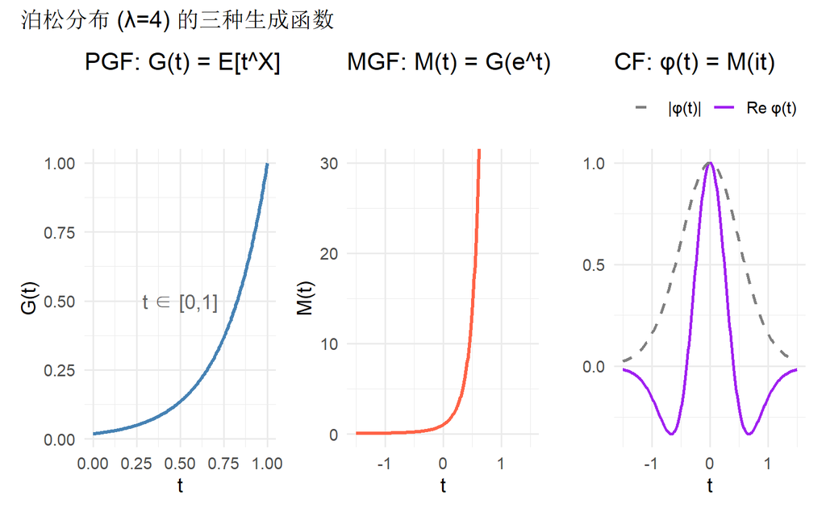

图 10: 以泊松分布为例：PGF、MGF、CF 三者的关系

```r
lambda <- 4
t_vals <- seq(-1.5, 1.5, length.out = 300)

# PGF: G(t) = exp(λ(t-1)), t ∈ [0,1]
t_pgf <- seq(0, 1, length.out = 200)
pgf_vals <- exp(lambda * (t_pgf - 1))

# MGF: M(t) = exp(λ(e^t - 1))
mgf_vals <- exp(lambda * (exp(t_vals) - 1))

# CF: φ(t) = exp(λ(e^{it} - 1))，取模
cf_mod <- Mod(exp(lambda * (exp(1i * t_vals) - 1)))
cf_re  <- Re(exp(lambda * (exp(1i * t_vals) - 1)))

p_pgf <- ggplot(data.frame(t = t_pgf, G = pgf_vals), aes(t, G)) +
  geom_line(linewidth = 1.2, color = "steelblue") +
  labs(x = "t", y = "G(t)", title = "PGF: G(t) = E[t^X]") +
  annotate("text", x = 0.5, y = 0.5, label = "t ∈ [0,1]", color = "gray40")

p_mgf <- ggplot(data.frame(t = t_vals, M = mgf_vals), aes(t, M)) +
  geom_line(linewidth = 1.2, color = "tomato") +
  coord_cartesian(ylim = c(0, 30)) +
  labs(x = "t", y = "M(t)", title = "MGF: M(t) = G(e^t)")

p_cf <- ggplot(data.frame(t = t_vals, Re = cf_re, Mod = cf_mod)) +
  geom_line(aes(t, Re, color = "Re φ(t)"), linewidth = 1) +
  geom_line(aes(t, Mod, color = "|φ(t)|"), linewidth = 1, linetype = "dashed") +
  scale_color_manual(values = c("Re φ(t)" = "purple", "|φ(t)|" = "gray50")) +
  labs(x = "t", y = "", title = "CF: φ(t) = M(it)", color = "") +
  theme(legend.position = "top")

p_pgf + p_mgf + p_cf +
  plot_annotation(title = paste0("泊松分布 (λ=", lambda, ") 的三种生成函数"),
                  theme = theme(plot.title = element_text(size = 16)))
```

**重要定理 10.6（唯一性）**

$\varphi_X = \varphi_Y \iff \mathbb{P}_X = \mathbb{P}_Y$

特征函数**唯一确定**分布，就像指纹唯一确定一个人。

## 6 线性变换性质

设 $a, b \in \mathbb{R}$：

$$M_{a+bX}(t) = e^{at}\,M_X(bt), \qquad \varphi_{a+bX}(t) = e^{iat}\,\varphi_X(bt)$$

### 6.1 🧪 实验10：线性变换对MGF的影响

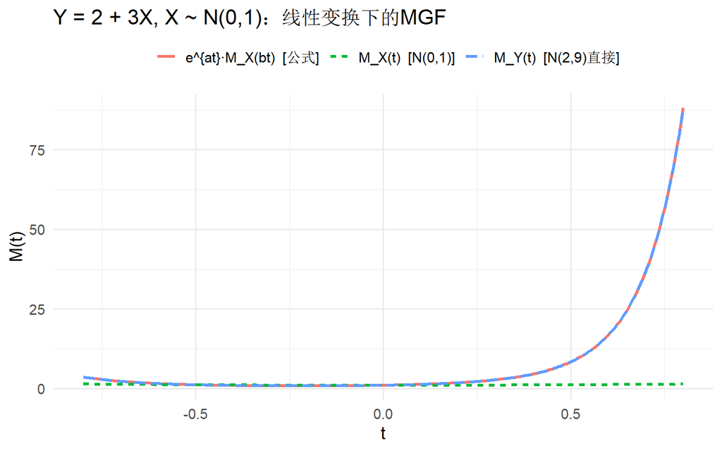

图 11: 对X做线性变换 Y=a+bX，MGF的变化清晰可见

```r
# X ~ N(0,1), Y = 2 + 3X ~ N(2, 9)
a <- 2; b <- 3
t_vals <- seq(-0.8, 0.8, length.out = 300)

mgf_X <- exp(t_vals^2 / 2)
mgf_Y_formula <- exp(a * t_vals) * exp((b * t_vals)^2 / 2)  # e^{at} M_X(bt)
mgf_Y_direct  <- exp((a) * t_vals + (b^2) * t_vals^2 / 2)   # N(2,9) 的 MGF

df_lin <- data.frame(
  t = rep(t_vals, 3),
  M = c(mgf_X, mgf_Y_formula, mgf_Y_direct),
  曲线 = rep(c("M_X(t)  [N(0,1)]",
               "e^{at}·M_X(bt)  [公式]",
               "M_Y(t)  [N(2,9)直接]"), each = length(t_vals))
)

ggplot(df_lin, aes(t, M, color = 曲线)) +
  geom_line(aes(linetype = 曲线), linewidth = 1.2) +
  labs(x = "t", y = "M(t)", color = "", linetype = "",
       title = "Y = 2 + 3X, X ~ N(0,1)：线性变换下的MGF") +
  theme(legend.position = "top")
```

## 7 独立和的乘积性质

设 $X_1, \ldots, X_n$ 独立，$S = \sum_{i=1}^n X_i$：

$$M_S(s) = \prod_{i=1}^n M_i(s), \qquad \varphi_S = \prod_{i=1}^n \varphi_i$$

### 7.1 🧪 实验11：模拟验证——独立指数之和是Gamma分布

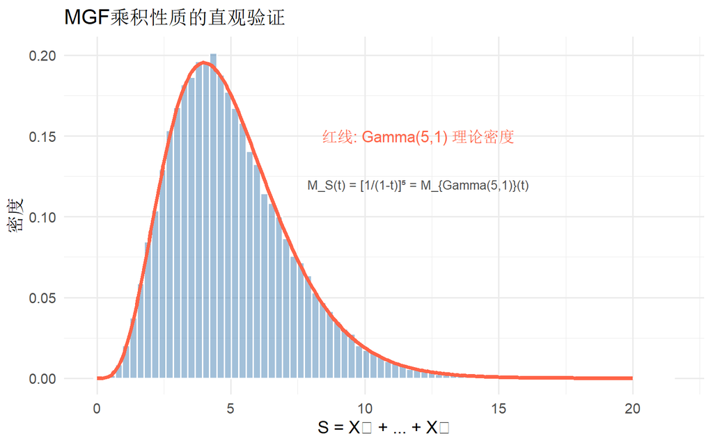

图 12: 5个独立Exp(1)之和 → Gamma(5,1)：直方图 vs 理论密度完美吻合

```r
set.seed(42)
n <- 5
N_sim <- 50000

# 生成 N_sim 个 S = X_1 + ... + X_n，每个 X_i ~ Exp(1)
S_samples <- rowSums(matrix(rexp(N_sim * n, rate = 1), ncol = n))

x_vals <- seq(0, 20, length.out = 300)

ggplot(data.frame(S = S_samples), aes(S)) +
  geom_histogram(aes(y = after_stat(density)), bins = 80,
                 fill = "steelblue", alpha = 0.5, color = "white") +
  geom_line(data = data.frame(x = x_vals, y = dgamma(x_vals, shape = n, rate = 1)),
            aes(x, y), color = "tomato", linewidth = 1.5) +
  annotate("text", x = 12, y = 0.15,
           label = "红线: Gamma(5,1) 理论密度", color = "tomato", size = 4.5) +
  labs(x = "S = X₁ + ... + X₅", y = "密度",
       title = "MGF乘积性质的直观验证") +
  annotate("text", x = 12, y = 0.12,
           label = "M_S(t) = [1/(1-t)]⁵ = M_{Gamma(5,1)}(t)",
           color = "gray30", size = 3.5)
```

## 8 密度生成（傅里叶逆变换）

设 $\varphi_X$ 可积，则 $X$ 的密度可由逆变换恢复：

$$f_X(x) = \frac{1}{2\pi} \int_{-\infty}^{\infty} e^{-itx}\,\varphi_X(t)\,dt$$

这在实验7中已经验证过。

## 9 应用：$\chi^2$-分布

### 9.1 定义

设 $X$ 的密度为：

$$f_X(x) = \frac{1}{\Gamma(k/2)}\left(\frac{1}{2}\right)^{k/2} x^{k/2-1} e^{-x/2} \cdot \mathbf{1}_{(0,\infty)}(x)$$

则 $X \sim \chi^2(k)$，$k$ 为**自由度**。其矩母函数为：

$$M_X(s) = \left(\frac{1}{1-2s}\right)^{k/2}, \quad s < \frac{1}{2}$$

### 9.2 定理 10.12

**重要**

设 $X_1, \ldots, X_n$ 独立，$X_i \sim N(0,1)$，则：
$$Y = \sum_{i=1}^n X_i^2 \sim \chi^2(n)$$

**证明思路**：$X_i^2 \sim \chi^2(1)$，其MGF为 $(1-2s)^{-1/2}$。由独立性，$Y$ 的MGF为各自MGF的乘积 $(1-2s)^{-n/2}$，恰好是 $\chi^2(n)$ 的MGF。由唯一性定理，$Y \sim \chi^2(n)$。

### 9.3 🧪 实验12：从正态到卡方——全过程可视化

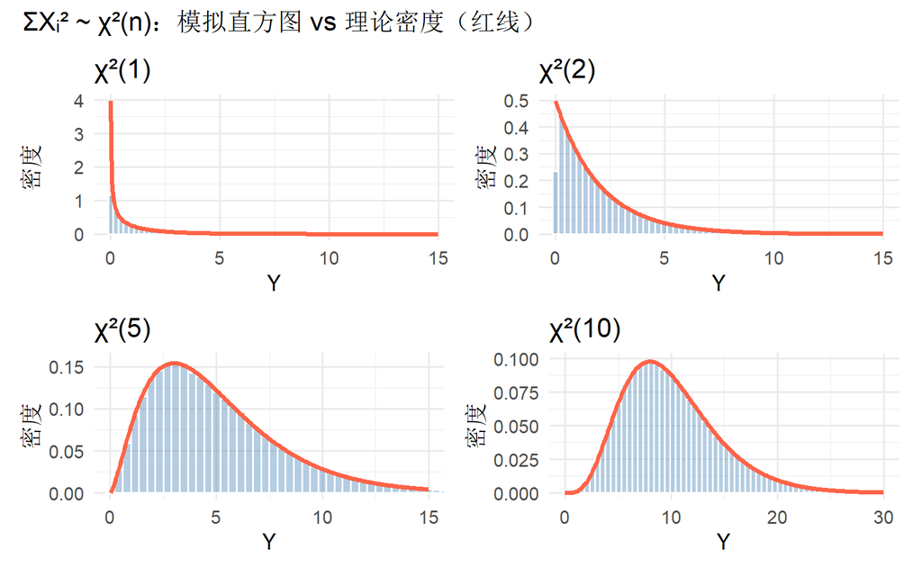

图 13: n个独立标准正态的平方和 → χ²(n)分布，随自由度增大逐渐右移

```r
set.seed(2024)
N_sim <- 100000

p_panels <- list()
for (k in c(1, 2, 5, 10)) {
  # 模拟：k个独立N(0,1)的平方和
  Y <- rowSums(matrix(rnorm(N_sim * k)^2, ncol = k))
  x_vals <- seq(0.01, max(k * 3, 15), length.out = 300)

  df_k <- data.frame(Y = Y)
  df_theory <- data.frame(x = x_vals, y = dchisq(x_vals, df = k))

  p_panels[[as.character(k)]] <-
    ggplot(df_k, aes(Y)) +
    geom_histogram(aes(y = after_stat(density)), bins = 80,
                   fill = "steelblue", alpha = 0.4, color = "white") +
    geom_line(data = df_theory, aes(x, y),
              color = "tomato", linewidth = 1.3) +
    labs(x = "Y", y = "密度", title = paste0("χ²(", k, ")")) +
    coord_cartesian(xlim = c(0, max(k * 3, 15)))
}

(p_panels[["1"]] + p_panels[["2"]]) / (p_panels[["5"]] + p_panels[["10"]]) +
  plot_annotation(
    title = "ΣXᵢ² ~ χ²(n)：模拟直方图 vs 理论密度（红线）",
    theme = theme(plot.title = element_text(size = 16))
  )
```

### 9.4 🧪 实验13：用MGF乘积性质证明卡方的可加性

$\chi^2$ 分布的一个重要性质：若 $U \sim \chi^2(m)$，$V \sim \chi^2(n)$，$U \perp V$，则 $U + V \sim \chi^2(m+n)$。

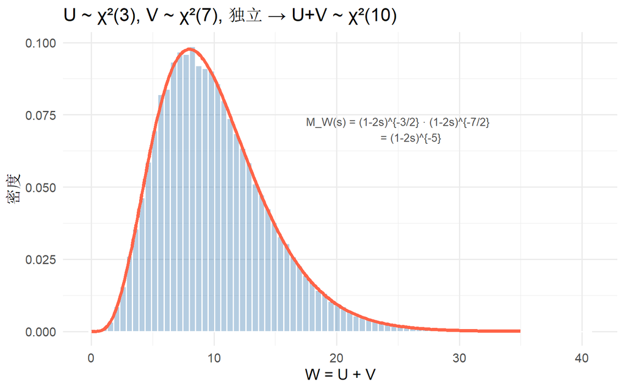

图 14: χ²可加性：χ²(3) + χ²(7) = χ²(10)——MGF乘积性质的直接推论

```r
set.seed(42)
N_sim <- 100000

U <- rchisq(N_sim, df = 3)
V <- rchisq(N_sim, df = 7)
W <- U + V

x_vals <- seq(0.01, 35, length.out = 300)

ggplot(data.frame(W = W), aes(W)) +
  geom_histogram(aes(y = after_stat(density)), bins = 80,
                 fill = "steelblue", alpha = 0.4, color = "white") +
  geom_line(data = data.frame(x = x_vals, y = dchisq(x_vals, df = 10)),
            aes(x, y), color = "tomato", linewidth = 1.5) +
  labs(x = "W = U + V", y = "密度",
       title = "U ~ χ²(3), V ~ χ²(7), 独立 → U+V ~ χ²(10)") +
  annotate("text", x = 25, y = 0.07,
           label = "M_W(s) = (1-2s)^{-3/2} · (1-2s)^{-7/2}\n        = (1-2s)^{-5}",
           color = "gray30", size = 3.5)
```

## 10 总结：三种生成函数的对比

```r
summary_df <- data.frame(
  特征 = c("定义", "适用范围", "是否总存在", "求矩方式", "核心用途"),
  概率母函数_PGF = c(
    "E[t^X]", "非负整数值 r.v.", "是（在|t|≤1）",
    "G^(n)(0) = n!·P(X=n)", "计数问题、分支过程"
  ),
  矩母函数_MGF = c(
    "E[e^{tX}]", "很多常见分布", "不一定（如柯西分布）",
    "M^(n)(0) = E[X^n]", "计算矩、识别分布"
  ),
  特征函数_CF = c(
    "E[e^{itX}]", "所有随机变量", "总是存在",
    "φ^(k)(0)/i^k = E[X^k]", "极限定理、密度反演"
  )
)

knitr::kable(summary_df, col.names = c("", "概率母函数 (PGF)", "矩母函数 (MGF)", "特征函数 (CF)"),
             caption = "三种生成函数对比")
```

表 1: 三种生成函数对比

[output not shown]

**提示记忆口诀**

**PGF** 管离散，**MGF** 生矩快，**CF** 最万能——不怕分布”刺头”，总能算出来。三者通过 $M_X(it) = \varphi_X(t)$ 和 $G_X(e^t) = M_X(t)$ 串联起来。

[output not shown]